# Avoidable Emergency Department Use in Georgia

County-level predictors of ambulatory care sensitive ER visits, 2019-2025

Ahmed Wiqar

November 11, 2026

# Research question

Ambulatory care sensitive conditions (ACSCs) are conditions for which timely, effective outpatient care should prevent the need for emergency treatment. High ACSC emergency department rates are therefore read as a signal of unmet primary care need rather than of population sickness alone.

**Question:** Which Georgia counties have the highest rates of avoidable ER use, and does that variation track with primary care physician supply?

**Headline finding:** It does not. Avoidable ER use tracks county *income*. Physician supply shows no independent association once income is controlled.

# Data sources

| Source | Content | Years | Notes |
| --- | --- | --- | --- |
| Georgia DPH OASIS | ER visits by county and cause | 2019-2025 | Georgia hospitals only |
| Georgia DPH OASIS | County population | 2019-2025 | Intercensal estimates |
| County Health Rankings | County characteristics | 2023 release | Treated as static |

Six ACSC categories were available in OASIS and are used here: diabetes, hypertension, hypertensive heart disease, hypertensive heart and chronic kidney disease, pneumonia, and asthma.

County Health Rankings measures are taken from the 2023 release only and treated as fixed county characteristics. Primary care supply, rurality, and median income move slowly relative to the seven-year study window, and the central analysis is cross-sectional rather than longitudinal.

```r
# Relative paths so the project runs on any machine.
# Requires an RStudio Project with the data in ./data/raw/
data_dir <- "data/raw"

f_er   <- file.path(data_dir, "oasis_er_acsc.xlsx")
f_pop  <- file.path(data_dir, "oasis_population.xlsx")
f_chr  <- file.path(data_dir, "chr_georgia_2023.xlsx")
```

# ER visits

## Import

OASIS exports wide: one column per year, plus a “Selected Causes Total” subtotal row for every county and a “County Summary” statewide row. Rows 1-4 of the file are title and two-row header formatting, so the real data begins at row 5 and column names are supplied manually.

```r
er_raw <- read_excel(f_er, skip = 4, col_names = FALSE)

names(er_raw) <- c("county", "fips", "cause",
                   "y2019", "y2020", "y2021", "y2022",
                   "y2023", "y2024", "y2025", "total")
```

## Reshape and clean

Three transformations happen here:

1. **Wide to long.** Year is a variable but arrives as column names. Nothing downstream (grouping, joining, filtering by year) works until it is a column.
2. **Drop aggregate rows.** Both the per-county cause subtotals and the statewide “County Summary” row would double-count if retained.
3. **Type coercion.** FIPS is kept as character because it is an identifier, not a quantity; leading zeros matter in other states and the habit is right.

```r
er <- er_raw |>
  select(-total) |>             # recomputable; would corrupt the pivot
  pivot_longer(
    starts_with("y"),
    names_to  = "year",
    values_to = "visits"
  ) |>
  mutate(
    county = str_trim(county),
    fips   = as.character(fips),
    cause  = str_trim(cause),
    year   = parse_number(year),          # "y2019" -> 2019
    visits = as.numeric(visits)
  ) |>
  filter(
    !str_detect(cause, "Selected Causes Total"),
    county != "County Summary",
    !is.na(county),
    !is.na(visits)
  )
```

## Validation

Expected dimensions: 159 counties x 6 causes x 7 years = 6,678 rows.

An earlier version of this import returned 6,720 rows across 160 geographies. Inspection identified a statewide aggregate row labelled “County Summary” — a label that does not obviously read as a total — which was then excluded.Row-count validation caught an error that visual inspection of the file did not.

```r
c(rows     = nrow(er),
  counties = n_distinct(er$county),
  causes   = n_distinct(er$cause),
  years    = n_distinct(er$year))
```

```
##     rows counties   causes    years
##     6678      159        6        7
```

```r
count(er, cause)
```

| cause | n |
| --- | --- |
| Asthma | 1113 |
| Diabetes | 1113 |
| High Blood Pressure (Hypertension) | 1113 |
| Hypertensive Heart Disease | 1113 |
| Hypertensive Heart and Chronic Kidney Disease | 1113 |
| Pneumonia | 1113 |

# Population

```r
pop_raw <- read_excel(f_pop, skip = 4, col_names = FALSE)

names(pop_raw) <- c("county", "fips",
                    "y2019", "y2020", "y2021", "y2022",
                    "y2023", "y2024", "y2025", "total")
```

```r
pop <- pop_raw |>
  select(-total) |>
  pivot_longer(
    starts_with("y"),
    names_to  = "year",
    values_to = "population"
  ) |>
  mutate(
    county     = str_trim(county),
    fips       = as.character(fips),
    year       = parse_number(year),
    population = as.numeric(population)
  ) |>
  filter(county != "County Summary", !is.na(county), !is.na(population))
```

```r
c(rows = nrow(pop), counties = n_distinct(pop$county))   # expect 1113, 159
```

```
##     rows counties
##     1113      159
```

## Join check

Verify key alignment *before* joining. Unmatched names are the most common cause of silently dropped rows, and a post-hoc row count cannot distinguish a clean join from one that lost twenty counties.

```r
list(
  in_er_not_pop = setdiff(er$county, pop$county),
  in_pop_not_er = setdiff(pop$county, er$county)
)
```

```
## $in_er_not_pop
## character(0)
##
## $in_pop_not_er
## character(0)
```

```r
# FIPS is included in the join key rather than left to duplicate as
# fips.x / fips.y. It is also a more reliable match than the name.
er_pop <- er |>
  inner_join(pop, by = c("county", "fips", "year"))

nrow(er_pop)   # must still be 6,678 — growth would indicate duplicate keys
```

```
## [1] 6678
```

## Rates

```r
er_rates <- er_pop |>
  group_by(county, fips, year) |>
  summarise(
    acsc_visits = sum(visits),
    # first() not sum(): population repeats across the six cause rows
    # for each county-year, so summing would multiply it by six.
    population  = first(population),
    .groups     = "drop"
  ) |>
  mutate(rate_per_10k = acsc_visits / population * 10000)

nrow(er_rates)   # expect 159 x 7 = 1,113
```

```
## [1] 1113
```

# County characteristics

County Health Rankings splits the measures across two sheets. Primary care physician ratio and uninsured percentage sit in “Ranked Measure Data”; rurality and median household income sit in “Additional Measure Data”. Both sheets carry a title row above the real header, hence `skip = 1`.

```r
chr_ranked <- read_excel(f_chr, sheet = "Ranked Measure Data", skip = 1)
chr_addl   <- read_excel(f_chr, sheet = "Additional Measure Data", skip = 1)
```

```r
ranked <- chr_ranked |>
  select(
    fips          = FIPS,
    county        = County,
    pcp_ratio     = `Primary Care Physicians Ratio`,
    uninsured_pct = `% Uninsured`
  )

addl <- chr_addl |>
  select(
    fips          = FIPS,
    rural_pct     = `% Rural`,
    median_income = `Median Household Income`
  )

chr <- ranked |>
  inner_join(addl, by = "fips") |>
  filter(!is.na(county)) |>           # drops the state-level summary row
  mutate(
    fips          = as.character(fips),
    county        = str_remove(str_trim(county), " County$"),
    # PCP ratio may arrive formatted as "1,890:1"; parse_number extracts 1890.
    # Higher ratio = WORSE access. Direction matters for interpretation.
    pcp_ratio     = parse_number(as.character(pcp_ratio)),
    uninsured_pct = as.numeric(uninsured_pct),
    rural_pct     = as.numeric(rural_pct),
    median_income = as.numeric(median_income)
  )

nrow(chr)   # expect 159
```

```
## [1] 159
```

```r
chr |> select(pcp_ratio, uninsured_pct, rural_pct, median_income) |> summary()
```

```
##    pcp_ratio     uninsured_pct     rural_pct        median_income
##  Min.   :  670   Min.   :10.10   Min.   :  0.2462   Min.   : 34883
##  1st Qu.: 1729   1st Qu.:15.61   1st Qu.: 41.7017   1st Qu.: 42967
##  Median : 2440   Median :17.01   Median : 64.7096   Median : 48717
##  Mean   : 3324   Mean   :17.31   Mean   : 60.4890   Mean   : 53883
##  3rd Qu.: 3906   3rd Qu.:18.81   3rd Qu.: 81.1427   3rd Qu.: 61413
##  Max.   :20171   Max.   :25.76   Max.   :100.0000   Max.   :120919
##  NAs    :13
```

Counties with no primary care physician appear as `NA` rather than as a ratio. This is meaningful missingness — the most extreme form of the access problem under study — and those counties are excluded from models involving `pcp_ratio` rather than imputed.

# Analysis dataset

```r
stopifnot(length(setdiff(er_rates$fips, chr$fips)) == 0)

analysis <- er_rates |>
  left_join(select(chr, -county), by = "fips")   # drop duplicate name column

stopifnot(nrow(analysis) == nrow(er_rates))      # join must not change row count

n_missing_pcp <- chr |> filter(is.na(pcp_ratio)) |> nrow()
n_missing_pcp   # 13 counties have no primary care physician on record
```

```
## [1] 13
```

The 13 counties with no primary care physician on record are excluded from models involving pcp_ratio, leaving 146 counties.

```r
dir.create("data/clean", recursive = TRUE, showWarnings = FALSE)
write_csv(analysis, "data/clean/er_rates.csv", na = "")      # county-year, for mapping
write_csv(er_pop,   "data/clean/er_by_cause.csv")   # cause detail, for breakdown
```

# Exploratory findings

## Is the final year complete?

```r
analysis |>
  group_by(year) |>
  summarise(
    total_visits   = sum(acsc_visits),
    statewide_rate = sum(acsc_visits) / sum(population) * 10000,
    .groups = "drop"
  )
```

| year | total_visits | statewide_rate |
| --- | --- | --- |
| 2019 | 189643 | 178.1839 |
| 2020 | 146056 | 136.0864 |
| 2021 | 157103 | 145.5596 |
| 2022 | 162916 | 149.0541 |
| 2023 | 176598 | 159.6197 |
| 2024 | 192662 | 171.9550 |
| 2025 | 189179 | 167.3743 |

2025 totals are consistent with 2024, so the year is complete and retained.

The series also records the pandemic clearly: the statewide rate fell from 178.2 per 10,000 in 2019 to 136.1 in 2020 as patients avoided emergency departments. Recovery has been incomplete — the 2025 rate of 167.4 remains below the 2019 baseline six years later.

## Which counties rank highest?

```r
analysis |>
  filter(year == 2024) |>
  arrange(desc(rate_per_10k)) |>
  select(county, population, acsc_visits, rate_per_10k) |>
  head(20)
```

| county | population | acsc_visits | rate_per_10k |
| --- | --- | --- | --- |
| Candler | 11164 | 396 | 354.7116 |
| Jenkins | 8853 | 307 | 346.7751 |
| Decatur | 29463 | 1007 | 341.7846 |
| Ware | 36537 | 1245 | 340.7505 |
| Brooks | 16290 | 555 | 340.6998 |
| Hancock | 8734 | 285 | 326.3110 |
| Jeff Davis | 15281 | 498 | 325.8949 |
| Wilkes | 9554 | 310 | 324.4714 |
| McDuffie | 21743 | 705 | 324.2423 |
| Mitchell | 20345 | 647 | 318.0143 |

[output cut: 10 more lines]

The highest-rate counties form a coherent geographic band across rural south and middle Georgia rather than a scatter of outliers.

Small-county rate instability was anticipated but is not severe here: only three of the top ten counties have populations under 10,000. Rather than excluding the 34 counties below that threshold, they are retained and flagged, with point size on the scatter encoding population.

## Which conditions drive volume?

```r
er_pop |>
  filter(year == 2024) |>
  group_by(cause) |>
  summarise(visits = sum(visits), .groups = "drop") |>
  arrange(desc(visits)) |>
  mutate(pct = round(100 * visits / sum(visits), 1))
```

| cause | visits | pct |
| --- | --- | --- |
| High Blood Pressure (Hypertension) | 57317 | 29.8 |
| Asthma | 41973 | 21.8 |
| Diabetes | 38786 | 20.1 |
| Pneumonia | 37135 | 19.3 |
| Hypertensive Heart and Chronic Kidney Disease | 9037 | 4.7 |
| Hypertensive Heart Disease | 8414 | 4.4 |

Hypertension alone accounts for 29.8% of avoidable visits; including the two hypertensive subtypes brings the cardiovascular share to 38.9%.

# Modelling

```r
d2024 <- analysis |>
  filter(year == 2024, !is.na(pcp_ratio)) |>
  mutate(income_10k = median_income / 10000)   # rescaled for readable coefficients
```

## Bivariate relationships

```r
d2024 |>
  select(rate_per_10k, pcp_ratio, uninsured_pct, rural_pct, median_income) |>
  cor(use = "complete.obs") |>
  round(3)
```

```
##               rate_per_10k pcp_ratio uninsured_pct rural_pct median_income
## rate_per_10k         1.000     0.031         0.253     0.117        -0.548
## pcp_ratio            0.031     1.000         0.152     0.299        -0.204
## uninsured_pct        0.253     0.152         1.000     0.331        -0.452
## rural_pct            0.117     0.299         0.331     1.000        -0.361
## median_income       -0.548    -0.204        -0.452    -0.361         1.000
```

Median income is the strongest correlate at r = -0.55. Primary care physician ratio is effectively uncorrelated at r = 0.03. Uninsured rate (0.25) and rurality (0.12) are weakly positive, but both are themselves correlated with income (-0.45 and -0.36), suggesting they may not carry independent signal.

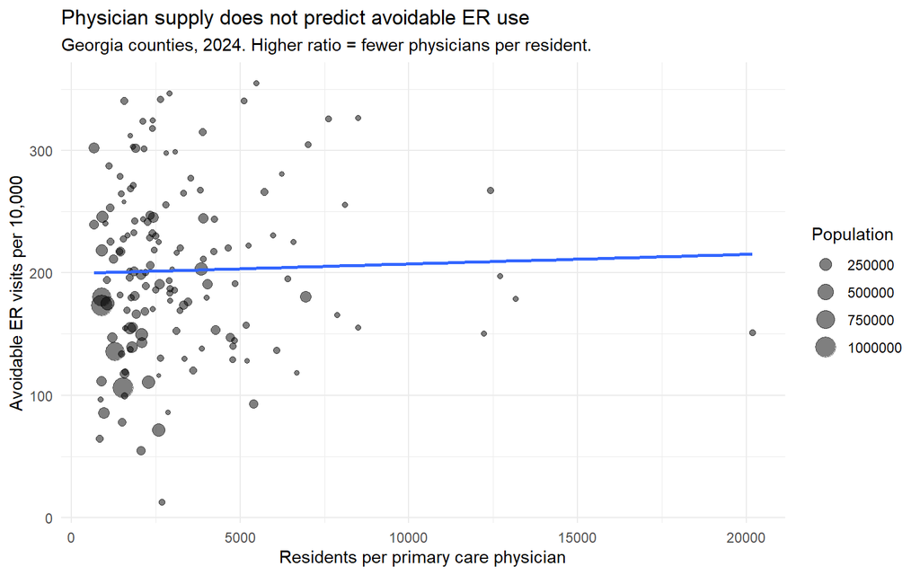

```r
ggplot(d2024, aes(pcp_ratio, rate_per_10k, size = population)) +
  geom_point(alpha = 0.5) +
  geom_smooth(method = "lm", se = FALSE, show.legend = FALSE) +
  labs(
    title    = "Physician supply does not predict avoidable ER use",
    subtitle = "Georgia counties, 2024. Higher ratio = fewer physicians per resident.",
    x = "Residents per primary care physician",
    y = "Avoidable ER visits per 10,000",
    size = "Population"
  ) +
  theme_minimal()
```

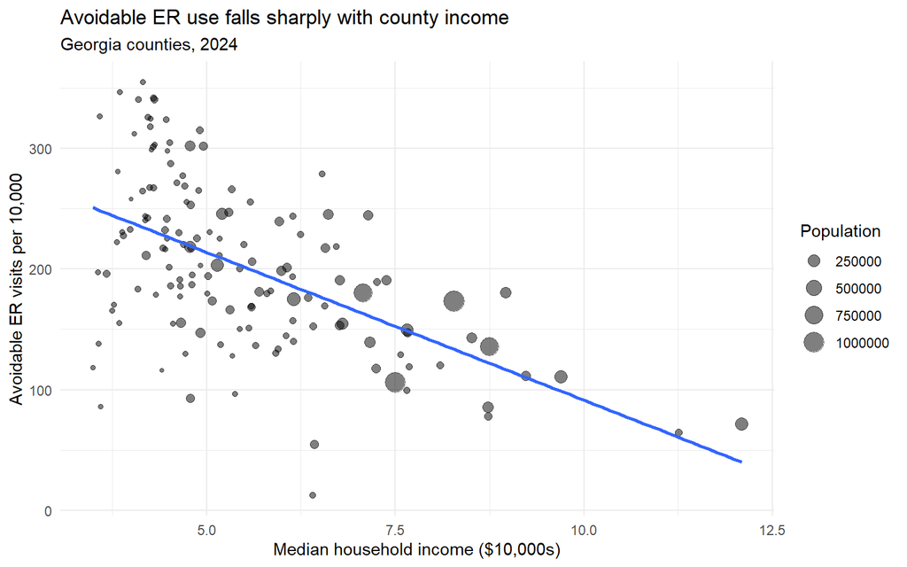

```r
ggplot(d2024, aes(income_10k, rate_per_10k, size = population)) +
  geom_point(alpha = 0.5) +
  geom_smooth(method = "lm", se = FALSE, show.legend = FALSE) +
  labs(
    title    = "Avoidable ER use falls sharply with county income",
    subtitle = "Georgia counties, 2024",
    x = "Median household income ($10,000s)",
    y = "Avoidable ER visits per 10,000",
    size = "Population"
  ) +
  theme_minimal()
```

## Multivariate model

```r
m <- lm(rate_per_10k ~ income_10k + pcp_ratio + uninsured_pct + rural_pct,
        data = d2024)
summary(m)
```

```
##
## Call:
## lm(formula = rate_per_10k ~ income_10k + pcp_ratio + uninsured_pct +
##     rural_pct, data = d2024)
##
## Residuals:
##      Min       1Q   Median       3Q      Max
## -164.112  -35.661   -1.677   39.016  119.890
##
## Coefficients:
##                 Estimate Std. Error t value Pr(>|t|)
## (Intercept)   347.372105  48.572051   7.152 4.26e-11 ***
## income_10k    -25.845764   3.634090  -7.112 5.27e-11 ***
## pcp_ratio      -0.001675   0.001853  -0.904    0.367
## uninsured_pct   0.791749   2.120785   0.373    0.709
## rural_pct      -0.199015   0.190767  -1.043    0.299
## ---
## Signif. codes:  0 '***' 0.001 '**' 0.01 '*' 0.05 '.' 0.1 ' ' 1
##
## Residual standard error: 58.34 on 141 degrees of freedom
## Multiple R-squared:  0.3124, Adjusted R-squared:  0.2929
## F-statistic: 16.02 on 4 and 141 DF,  p-value: 7.841e-11
```

Income is the only significant predictor (t = -7.11, p < 0.001). Each additional $10,000 of median household income is associated with **25.8 fewer avoidable ER visits per 10,000 residents** — roughly 15% of the statewide average rate. The model explains 31% of cross-county variation.

Physician ratio, uninsured rate, and rurality are all insignificant once income is included. Uninsured rate in particular falls from r = 0.25 bivariate to p = 0.71 in the model, consistent with it proxying income.

## Diagnostics

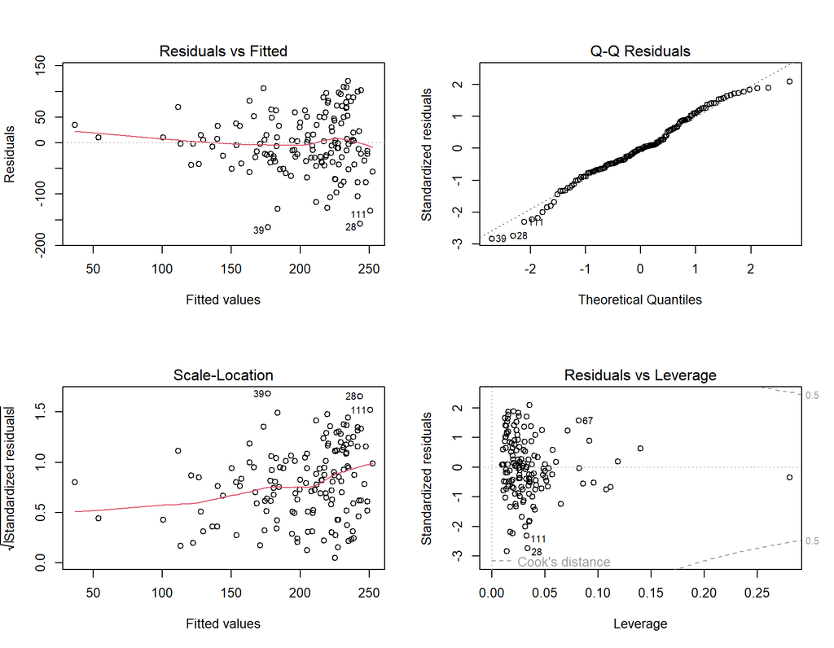

```r
par(mfrow = c(2, 2))
plot(m)
```

```r
par(mfrow = c(1, 1))
```

## Residual inspection

```r
d2024$resid <- residuals(m)

d2024 |>
  arrange(resid) |>
  select(county, population, median_income, rate_per_10k, resid) |>
  head(15)
```

| county | population | median_income | rate_per_10k | resid |
| --- | --- | --- | --- | --- |
| Dade | 16143 | 64054 | 12.38927 | -164.11237 |
| Clay | 2795 | 35957 | 85.86762 | -157.40629 |
| Randolph | 6170 | 34883 | 118.31442 | -132.53984 |
| Catoosa | 69359 | 64245 | 54.78741 | -128.62845 |
| Walker | 69724 | 47810 | 92.93787 | -126.57603 |
| Chattahoochee | 8391 | 53786 | 96.53200 | -115.12657 |
| Webster | 2331 | 44084 | 115.83012 | -105.88499 |
| Wheeler | 7325 | 35664 | 137.88396 | -103.92433 |
| Charlton | 13032 | 47229 | 129.68079 | -96.60935 |
| Clarke | 130750 | 49145 | 147.22753 | -82.19061 |

[output cut: 5 more lines]

**Cross-border care.** Dade (-164), Catoosa (-129), and Walker (-127) sit in the Chattanooga metropolitan area on the Tennessee line. Dade’s observed rate of 12.4 per 10,000 against a statewide average near 172 is not plausible as true utilisation. Charlton, near Jacksonville, shows the same pattern. Because OASIS captures visits to *Georgia* hospitals, out-of-state emergency care is invisible to this measure. Chattahoochee County adds a related mechanism: Fort Benning’s on-post military facilities also fall outside civilian discharge reporting.

**Geographic inaccessibility.** Clay (pop. 2,795), Webster (2,331), Wheeler, and Wilcox are small, poor, and distant from any emergency department. The measure cannot record avoidable ER use where no ER is reachable — meaning it likely understates unmet need precisely where that need is greatest.

**Unexplained.** Clarke, Lowndes, and Bulloch are university counties and underpredict, which suggests denominator composition — large young, healthy student populations — as a candidate explanation. This was tested informally against Baldwin and Bibb, which also host universities and do *not* follow the pattern. The hypothesis is noted but not supported and is not claimed here.

# Conclusions

1. **Income, not physician supply, predicts avoidable ER use in Georgia.** Each $10,000 of median household income is associated with 25.8 fewer avoidable visits per 10,000 residents; income alone explains 30% of cross-county variation.
2. **Primary care physician ratio shows no association** with avoidable ER use, bivariate or controlled. Access policy framed around physician supply may target the wrong lever.
3. **The measure has a geographic blind spot.** Counties adjacent to out-of-state metropolitan areas systematically undercount, and remote counties without nearby emergency departments understate need rather than demonstrating its absence.

## Further work

- Test the cross-border hypothesis directly using distance to the nearest ER, including out-of-state facilities.
- Stratify by payor. OASIS supports self-pay and PeachCare breakdowns, which would speak more directly to coverage than the uninsured rate does.
- Extend to a panel specification with county fixed effects to exploit the seven-year window.
- Replace the PCP ratio with measures of effective access: Medicaid acceptance, NP and FQHC capacity, and cross-county care-seeking. Physician supply varies thirty-fold here yet predicts nothing, which may reflect how access is measured rather than whether it matters.